# Banking Risk Assessment Model

## Problem Statement

Develop a basic understanding of risk analytics in banking and financial services and understand how data is used to minimize the risk of losing money while lending to customers.

## Solution

Help the company make a decision based on the applicant's profile like if the applicant is likely to repay the loan then approving the loan otherwise not.

## Dataset

The dataset contains detailed information about bank clients, their financial accounts, and loan applications. It is organized into multiple tables connected through primary and foreign keys, enabling analysis of customer demographics, account balances, and risk factors.

Key identifiers and their meanings include:

BRId: Branch type

- 1 = Retail
- 2 = Institutional
- 3 = Private Bank
- 4 = Commercial

GenderId: Gender of the client

- 1 = Male
- 2 = Female

IAId: Unique identifier for a specific Investment Advisor assigned to the client.

```python
import pandas as pd
import matplotlib.pyplot as plt
import seaborn as sns
import numpy as np
```

```python
df = pd.read_csv('/content/sample_data/Banking.csv')
df.head()
```

|  | Client ID | Name | Age | Location ID | Joined Bank | Banking Contact | Nationality | Occupation | Fee Structure | Loyalty Classification | ... | Bank Deposits | Checking Accounts | Saving Accounts | Foreign Currency Account | Business Lending | Properties Owned | Risk Weighting | BRId | GenderId | IAId |
| --- | --- | --- | --- | --- | --- | --- | --- | --- | --- | --- | --- | --- | --- | --- | --- | --- | --- | --- | --- | --- | --- |
| 0 | IND81288 | Raymond Mills | 24 | 34324 | 06-05-2019 | Anthony Torres | American | Safety Technician IV | High | Jade | ... | 1485828.64 | 603617.88 | 607332.46 | 12249.96 | 1134475.30 | 1 | 2 | 1 | 1 | 1 |
| 1 | IND65833 | Julia Spencer | 23 | 42205 | 10-12-2001 | Jonathan Hawkins | African | Software Consultant | High | Jade | ... | 641482.79 | 229521.37 | 344635.16 | 61162.31 | 2000526.10 | 1 | 3 | 2 | 1 | 2 |
| 2 | IND47499 | Stephen Murray | 27 | 7314 | 25-01-2010 | Anthony Berry | European | Help Desk Operator | High | Gold | ... | 1033401.59 | 652674.69 | 203054.35 | 79071.78 | 548137.58 | 1 | 3 | 3 | 2 | 3 |
| 3 | IND72498 | Virginia Garza | 40 | 34594 | 28-03-2019 | Steve Diaz | American | Geologist II | Mid | Silver | ... | 1048157.49 | 1048157.49 | 234685.02 | 57513.65 | 1148402.29 | 0 | 4 | 4 | 1 | 4 |
| 4 | IND60181 | Melissa Sanders | 46 | 41269 | 20-07-2012 | Shawn Long | American | Assistant Professor | Mid | Platinum | ... | 487782.53 | 446644.25 | 128351.45 | 30012.14 | 1674412.12 | 0 | 3 | 1 | 2 | 5 |

5 rows × 25 columns

# Initial Exploration

```python
df.shape
```

```
(3000, 25)
```

```python
df.info()
```

```
<class 'pandas.core.frame.DataFrame'>
RangeIndex: 3000 entries, 0 to 2999
Data columns (total 25 columns):
 #   Column                    Non-Null Count  Dtype
---  ------                    --------------  -----
 0   Client ID                 3000 non-null   object
 1   Name                      3000 non-null   object
 2   Age                       3000 non-null   int64
 3   Location ID               3000 non-null   int64
 4   Joined Bank               3000 non-null   object
 5   Banking Contact           3000 non-null   object
 6   Nationality               3000 non-null   object
 7   Occupation                3000 non-null   object
 8   Fee Structure             3000 non-null   object
 9   Loyalty Classification    3000 non-null   object
```

[output cut: 17 more lines]

```python
df.describe()
```

|  | Age | Location ID | Estimated Income | Superannuation Savings | Amount of Credit Cards | Credit Card Balance | Bank Loans | Bank Deposits | Checking Accounts | Saving Accounts | Foreign Currency Account | Business Lending | Properties Owned | Risk Weighting | BRId | GenderId | IAId |
| --- | --- | --- | --- | --- | --- | --- | --- | --- | --- | --- | --- | --- | --- | --- | --- | --- | --- |
| count | 3000.000000 | 3000.000000 | 3000.000000 | 3000.000000 | 3000.000000 | 3000.000000 | 3.000000e+03 | 3.000000e+03 | 3.000000e+03 | 3.000000e+03 | 3000.000000 | 3.000000e+03 | 3000.000000 | 3000.000000 | 3000.000000 | 3000.000000 | 3000.000000 |
| mean | 51.039667 | 21563.323000 | 171305.034263 | 25531.599673 | 1.463667 | 3176.206943 | 5.913862e+05 | 6.715602e+05 | 3.210929e+05 | 2.329084e+05 | 29883.529993 | 8.667598e+05 | 1.518667 | 2.249333 | 2.559333 | 1.504000 | 10.425333 |
| std | 19.854760 | 12462.273017 | 111935.808209 | 16259.950770 | 0.676387 | 2497.094709 | 4.575570e+05 | 6.457169e+05 | 2.820796e+05 | 2.300078e+05 | 23109.924010 | 6.412303e+05 | 1.102145 | 1.131191 | 1.007713 | 0.500067 | 5.988242 |
| min | 17.000000 | 12.000000 | 15919.480000 | 1482.030000 | 1.000000 | 1.170000 | 0.000000e+00 | 0.000000e+00 | 0.000000e+00 | 0.000000e+00 | 45.000000 | 0.000000e+00 | 0.000000 | 1.000000 | 1.000000 | 1.000000 | 1.000000 |
| 25% | 34.000000 | 10803.500000 | 82906.595000 | 12513.775000 | 1.000000 | 1236.630000 | 2.396281e+05 | 2.044004e+05 | 1.199475e+05 | 7.479440e+04 | 11916.542500 | 3.748251e+05 | 1.000000 | 1.000000 | 2.000000 | 1.000000 | 5.000000 |
| 50% | 51.000000 | 21129.500000 | 142313.480000 | 22357.355000 | 1.000000 | 2560.805000 | 4.797934e+05 | 4.633165e+05 | 2.428157e+05 | 1.640866e+05 | 24341.190000 | 7.113147e+05 | 2.000000 | 2.000000 | 3.000000 | 2.000000 | 10.000000 |
| 75% | 69.000000 | 32054.500000 | 242290.305000 | 35464.740000 | 2.000000 | 4522.632500 | 8.258130e+05 | 9.427546e+05 | 4.348749e+05 | 3.155750e+05 | 41966.392500 | 1.185110e+06 | 2.000000 | 3.000000 | 3.000000 | 2.000000 | 15.000000 |
| max | 85.000000 | 43369.000000 | 522330.260000 | 75963.900000 | 3.000000 | 13991.990000 | 2.667557e+06 | 3.890598e+06 | 1.969923e+06 | 1.724118e+06 | 124704.870000 | 3.825962e+06 | 3.000000 | 5.000000 | 4.000000 | 2.000000 | 22.000000 |

```python
bins = [0, 100000, 300000, float('inf')]
labels = ['Low', 'Medium', 'High']

df['Income Band'] = pd.cut(df['Estimated Income'], bins=bins, labels=labels, right=False)
```

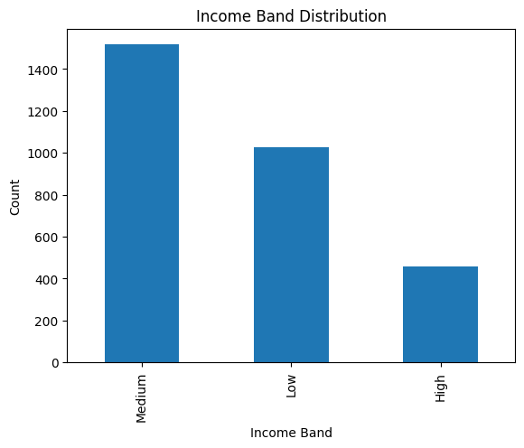

```python
df['Income Band'].value_counts().plot(kind='bar')
plt.xlabel('Income Band')
plt.ylabel('Count')
plt.title('Income Band Distribution')
plt.show()
```

```python
# Examine the distribution of unique categories in categorical columns
categorical_cols = df[['BRId', "GenderId", "IAId", "Amount of Credit Cards",
                       "Nationality", "Occupation", "Fee Structure",
                       "Loyalty Classification", "Properties Owned",
                       "Risk Weighting", "Income Band"]].columns
for col in categorical_cols:
    print(f"Value Counts for {col}:")
    display(df[col].value_counts())
```

```
Value Counts for BRId:
```

| BRId | count |
| --- | --- |
| 3 | 1352 |
| 1 | 660 |
| 2 | 495 |
| 4 | 493 |

**dtype:** int64

```
Value Counts for GenderId:
```

| GenderId | count |
| --- | --- |
| 2 | 1512 |
| 1 | 1488 |

**dtype:** int64

```
Value Counts for IAId:
```

| IAId | count |
| --- | --- |
| 1 | 177 |
| 2 | 177 |
| 3 | 177 |
| 4 | 177 |
| 8 | 177 |
| 9 | 176 |
| 13 | 176 |
| 12 | 176 |
| 10 | 176 |
| 11 | 176 |
| 14 | 176 |
| 15 | 176 |
| 6 | 89 |
| 5 | 89 |
| 7 | 89 |
| 16 | 88 |
| 17 | 88 |
| 18 | 88 |
| 19 | 88 |
| 20 | 88 |
| 21 | 88 |
| 22 | 88 |

**dtype:** int64

```
Value Counts for Amount of Credit Cards:
```

| Amount of Credit Cards | count |
| --- | --- |
| 1 | 1922 |
| 2 | 765 |
| 3 | 313 |

**dtype:** int64

```
Value Counts for Nationality:
```

| Nationality | count |
| --- | --- |
| European | 1309 |
| Asian | 754 |
| American | 507 |
| Australian | 254 |
| African | 176 |

**dtype:** int64

```
Value Counts for Occupation:
```

| Occupation | count |
| --- | --- |
| Associate Professor | 28 |
| Structural Analysis Engineer | 28 |
| Recruiter | 25 |
| Account Coordinator | 24 |
| Human Resources Manager | 24 |
| ... | ... |
| Office Assistant IV | 8 |
| Automation Specialist I | 7 |
| Computer Systems Analyst I | 6 |
| Developer III | 5 |
| Senior Sales Associate | 4 |

195 rows × 1 columns

**dtype:** int64

```
Value Counts for Fee Structure:
```

| Fee Structure | count |
| --- | --- |
| High | 1476 |
| Mid | 962 |
| Low | 562 |

**dtype:** int64

```
Value Counts for Loyalty Classification:
```

| Loyalty Classification | count |
| --- | --- |
| Jade | 1331 |
| Silver | 767 |
| Gold | 585 |
| Platinum | 317 |

**dtype:** int64

```
Value Counts for Properties Owned:
```

| Properties Owned | count |
| --- | --- |
| 2 | 777 |
| 1 | 776 |
| 3 | 742 |
| 0 | 705 |

**dtype:** int64

```
Value Counts for Risk Weighting:
```

| Risk Weighting | count |
| --- | --- |
| 2 | 1222 |
| 1 | 836 |
| 3 | 460 |
| 4 | 322 |
| 5 | 160 |

**dtype:** int64

```
Value Counts for Income Band:
```

| Income Band | count |
| --- | --- |
| Medium | 1517 |
| Low | 1027 |
| High | 456 |

**dtype:** int64

# Univariate Analysis

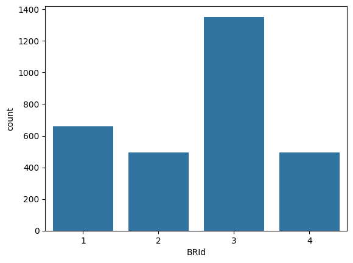

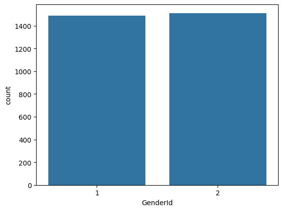

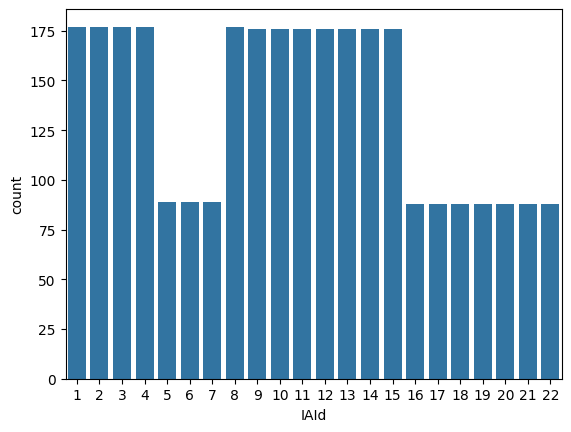

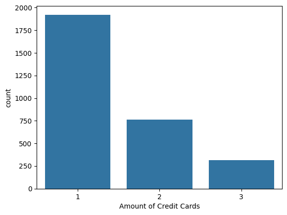

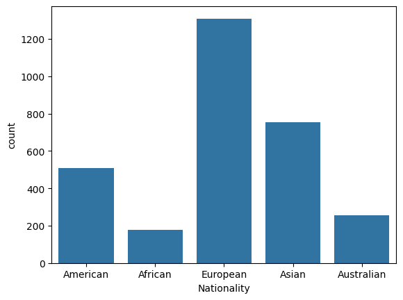

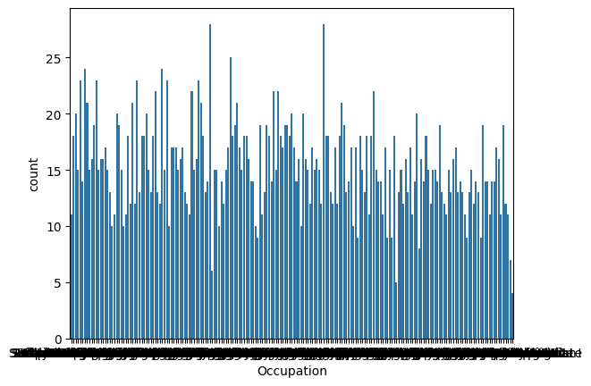

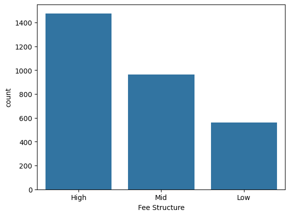

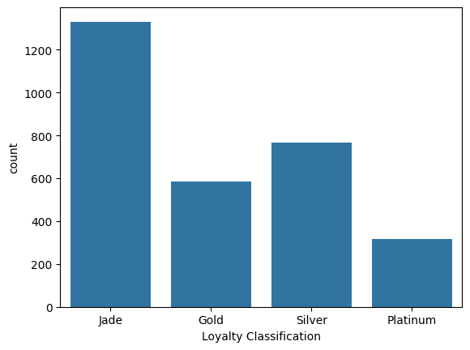

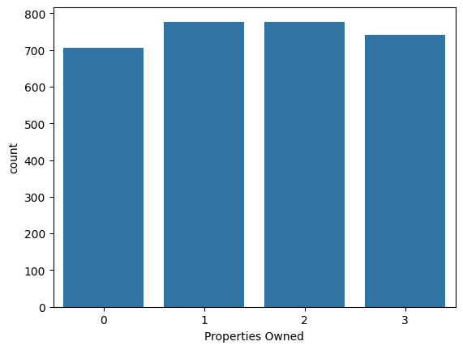

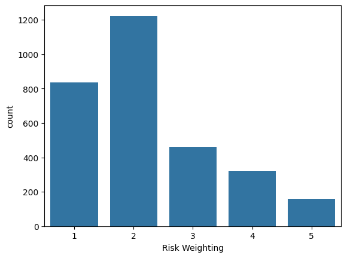

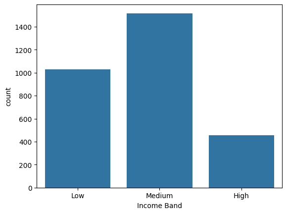

```python
for i, predictor in enumerate(categorical_cols):
    plt.figure(i)
    sns.countplot(data=df, x=predictor)
```

# Bivariate Analysis

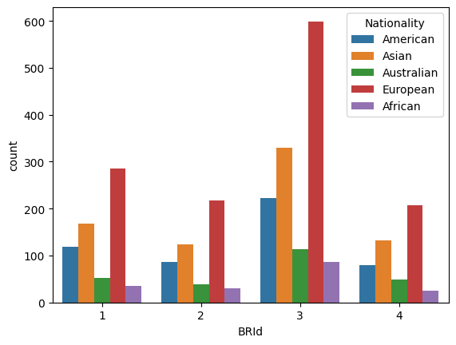

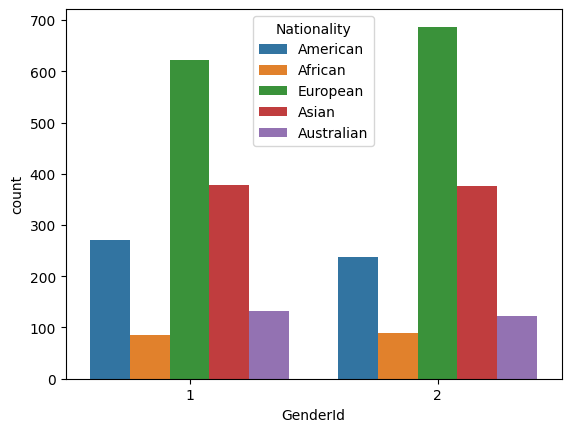

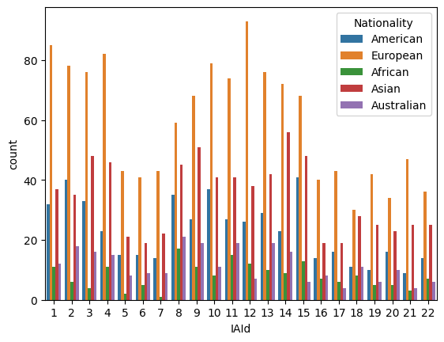

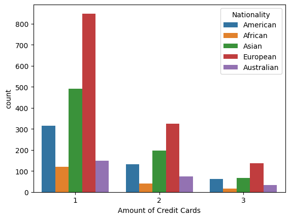

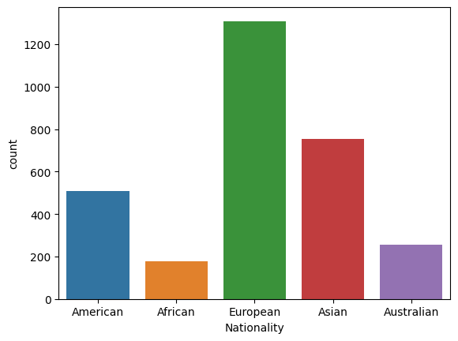

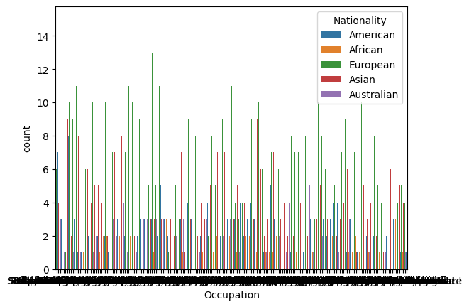

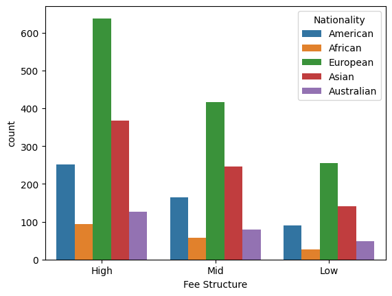

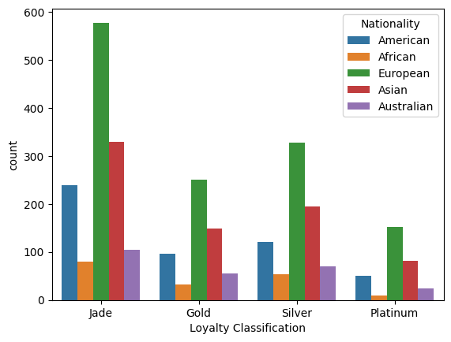

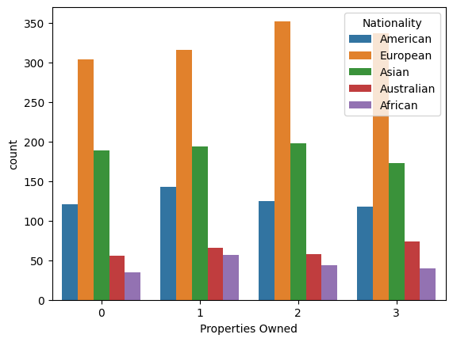

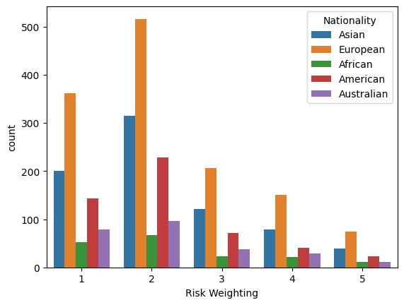

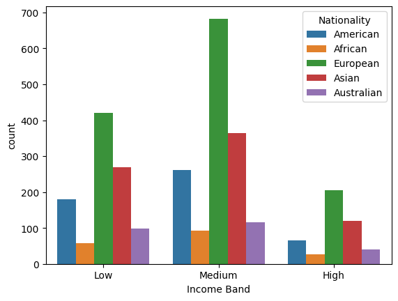

```python
for i, predictor in enumerate(categorical_cols):
    plt.figure(i)
    sns.countplot(data=df, x=predictor, hue='Nationality')
```